## Практична робота №6.Графи. Найкоротші шляхи

# Мета : набути практичних навичок розв’язання задач пошуку найкоротших шляхів у графі та оцінювання їх асимптотичної складності.

# 1 . Завдання полягає у знаходженні найкоротших шляхів від вершини 1 до всіх інших за допомогою алгоритму,вказаному у варіанті(Белмена Форда).

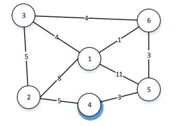

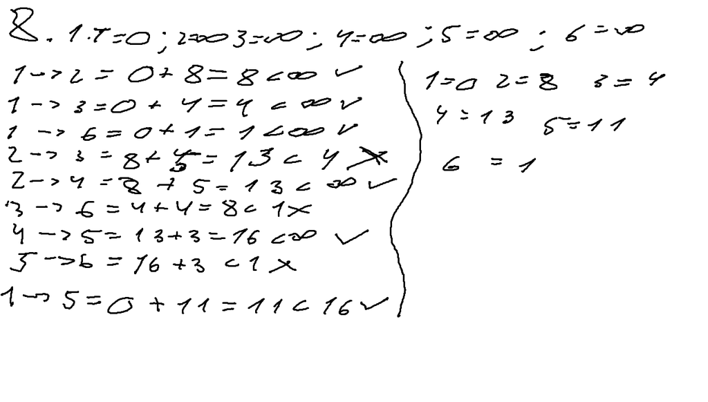

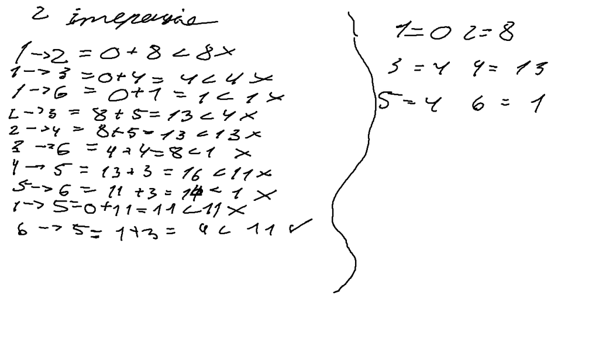

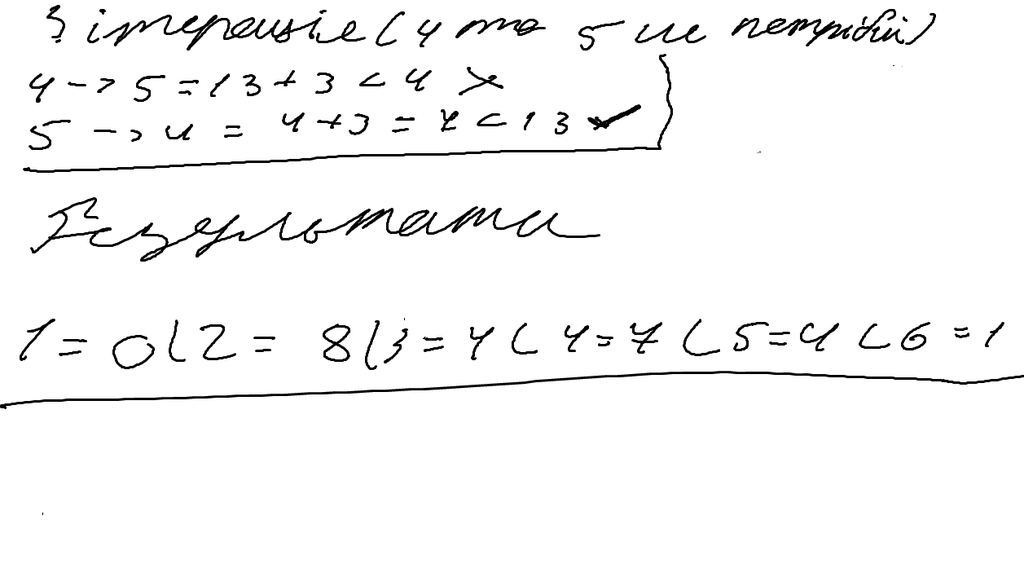

# 2 . Контрольні питання

- Що таке граф і які головні складові його структури? - Граф це структура яку використовують для моделювання відношень між обєктами , складається з вершин та ребер.
- Які алгоритми використовуються для пошуку найкоротших шляхів у графах - Дейкстри , Беллмана Форда та Флойда Вершелла.
- Як працює алгоритм Дейкстри і які його особливості? - 1. Ініціалізуємо масив де початкова вершина 0 , а всі інші нескінченність також створюєм множину невідвіданмих вершин (усі вершини) та множину відвіданих.Поки множина невідвіданих вершин не порожня: 1. Вибрати вершину з множини невідвіданих вершин з найменшою поточною відстанню від початкової вершини. 2. Видалити вершину з множини невідвіданих вершин та додати її до множини відвіданих вершин . 3. Для кожного сусіда вершини (тобто для кожної вершини, з'єднаної з вершиною ребром): 4. Обчислити нову відстань до сусідньої вершини через нова_відстань = відстань вершини + вага_ребра(вершина та сусідня вершина). 5. Якщо нова_відстань менша за поточну відстань до сусідньої , оновити відстань сусідньої до нова_відстань. З особливостей те що не може бути використаний з відємними вагами ребер також він дуже ефективний.
- Що таке алгоритм Белмена–Форда і коли його варто застосовувати? - це алгоритм який використовують для пошуку найкоротших шляхів від однієї точки до інших , приклад використання є в цьому пз.Його основною фішкою є те що його можно використати у графах з відємними ребрами , саме в цих графах його краще використовувати.
- Як працює алгоритм Флойда–Форшала і які його переваги та недоліки? - це алгоритм який використовують для пошуку найкоротших шляхів між усіма парами вершин у зваженому графі. Переваги - проста реалізація , знаходить найкоротші шляхі між всіма парами вершин , може працювати з відємними вагами ребер.Недоліки - висока асимптотична складність , не виявляє цикли з від'ємною сумою ваг безпосередньо.

# 3 . Висновок

На цьому практичному занятті ми набули практичних навичок роз'язання задач на пошук найкоротших шляхів у графі та оцінювання їх асимптотичної складності.